# Analyzing International Soccer Games 1872-2022

Shira Zur, Deeana Nasrulai, Nathan Beh

11/14/2022

## About the Data:

The visualizations below focus on various relationships we observed and analyzed in our soccer results data. The first visualization looks at the total number of goals scored by each country over time, ranging from 1872 to present day. The second visualization focuses on the Home Game Advantage, a theory that states that a team playing at their home stadium are more likely to win, rather than when they play away at the opposing team’s stadium. The visualization compares the home win ratio versus the away win ratio over each decade. Lastly, the third visualization compares the team performance of two teams – England and Scotland. The line graph visualization shows the total number of goals scored by the two teams over time. We hope our visualizations help improve the analysis of soccer teams and soccer games and show how versatile soccer analysis can be.

## World Density Map

This World Density Map shows the total number of goals scored by each country from 1872-2022.

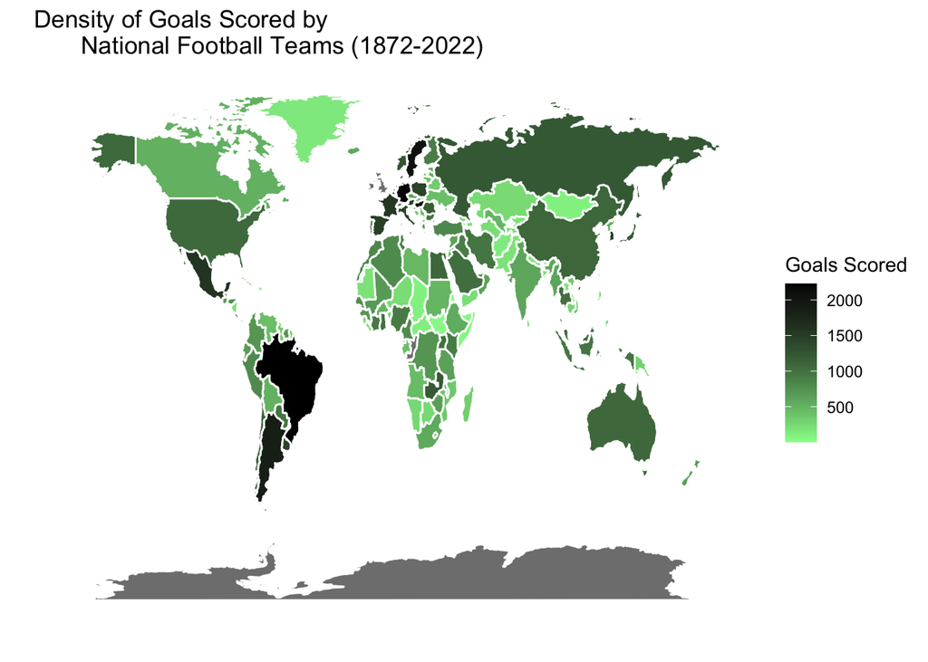

This goal density visualization allows us to see a big picture overview of National team performances from the start of data collection. This could provide analysis that could help national teams/players/supporters be informed on the status of their team’s success. This also informs us which team has been the most dominant in the history of soccer.

## Home vs. Away Bar Chart

This Home vs. Away Wins Ratio Bar Chart shows the overall home ratio (home wins out of total home games) and away ratio (away wins out of total away games) during every decade.

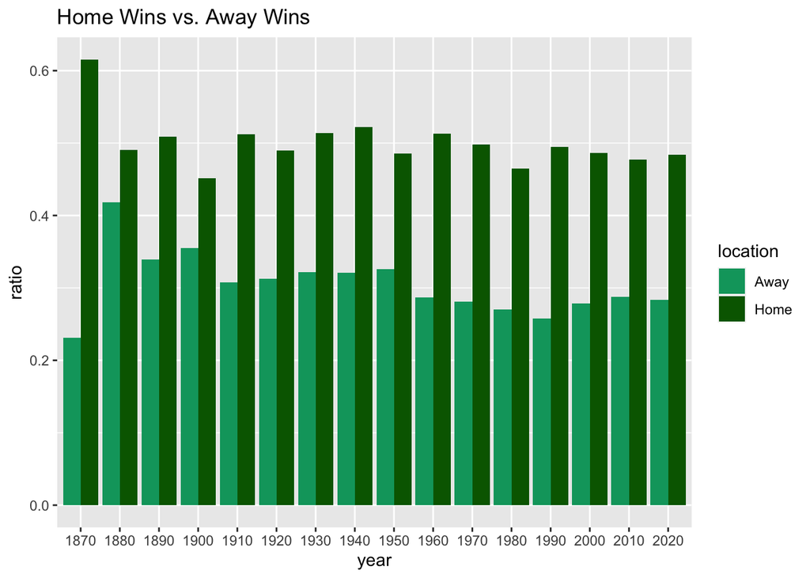

This bar chart proves the home game advantage theory – a theory that states that teams that play a match in their home city are more likely to win than teams that play a match away, at a city they are not from. This bar chart could help team managers and coaches that are worried that the home game advantage may no longer serve them; they can refer to this analysis and see that when they play home, they will be much more likely to win, and therefore need to prepare their teams when they play away.

## England vs. Scotland Line Graph

This line graph shows the total number of goals (home and away) scored by England vs Scotland from 2018-2022.

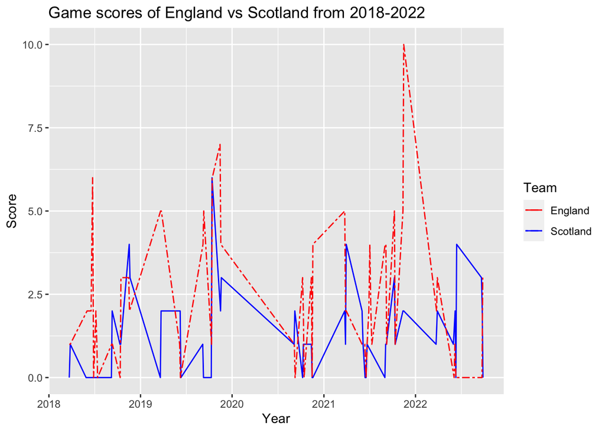

This line graph allows us to compare the performance of two teams (in this case, Scotland and England). This information is useful because it allows key stakeholders such as coaches, fans, and investors to make decisions about which team to support financially / emotionally and whether a team has improved over time or not. It can also indicate things specific to an opposing team, for example, if England tends to lose more games to Scotland as opposed to other countries.

## Summary Table

| team | home.goals | away.goals | total_goals |
| --- | --- | --- | --- |
| Abkhazia | 36 | 12 | 48 |
| Afghanistan | 54 | 72 | 126 |
| Åland Islands | 47 | 26 | 73 |
| Albania | 212 | 122 | 334 |
| Alderney | 5 | 10 | 15 |
| Algeria | 572 | 228 | 800 |
| American Samoa | 24 | 12 | 36 |
| Andalusia | 23 | 2 | 25 |
| Andorra | 38 | 26 | 64 |
| Angola | 265 | 167 | 432 |
| Anguilla | 14 | 24 | 38 |
| Antigua and Barbuda | 172 | 111 | 283 |
| Arameans Suryoye | 6 | 10 | 16 |
| Argentina | 1236 | 639 | 1875 |
| Armenia | 133 | 104 | 237 |
| Artsakh | 12 | 20 | 32 |
| Aruba | 96 | 66 | 162 |
| Australia | 699 | 382 | 1081 |
| Austria | 864 | 583 | 1447 |
| Aymara | 0 | 1 | 1 |
| Azerbaijan | 115 | 86 | 201 |
| Bahamas | 37 | 17 | 54 |
| Bahrain | 455 | 199 | 654 |
| Bangladesh | 131 | 69 | 200 |
| Barawa | 16 | 0 | 16 |
| Barbados | 229 | 120 | 349 |
| Basque Country | 85 | 71 | 156 |
| Belarus | 168 | 157 | 325 |
| Belgium | 879 | 551 | 1430 |
| Belize | 53 | 37 | 90 |

[output cut: 271 more lines]